# A Primer to R - Example Data Analysis

```r
print("Hello World!")
```

```
[1] "Hello World!"
```

Great! Now let’s prepare the workbook by emptying the current RStudio environment and setting the working path:

```r
# Empty current environment
rm(list = ls())
# Import Data
setwd(dirname(rstudioapi::getActiveDocumentContext()$path))
getwd()
```

```
[1] "C:/Users/soenk/Documents/GitHub/rPsychIntro/inst/tutorials/2-dataAnalysis"
```

# Install Libraries

Throughout this workbook, we will work with multiple external libraries (So, collection of code other people have written, so you don’t have to). Let’s install them:

```r
install.packages("ggplot2") #For excessive plots!
```

[output not shown]

```r
install.packages("moments") #For checking how normal data is!
install.packages("ggplot2")
```

# Importing the data

- user_dat.csv: This represents the participant data we’ve acquired through a PC questionnaire
- iq_dat.csv: This includes the iq test scores per participant from the IQ test software we’ve used in the experiment.
- creat_scores.csv: This file includes the creativity ratings per participant.

To load the data into the environment of R, we need to read the csv, which conveniently happens using the *read.csv()*-function! Let’s look at how this works, reading out the *user_dat.csv* file and assigning the data to an own variable, called *raw_user*, raw, because we have not processed/changed any of the data yet.

```r
raw_user <- read.csv("data//user_dat.csv", sep = ";")
```

What’s happening here? we define the new variable *raw_user* with *<-*. The *read.csv()* function takes two so-called *arguments*! Arguments are specifications which let a function know how to do the thing it’s supposed to do, but in the correct way! We can find two arguments for this function, separated by a comma, *,*:

- In this case, the function obviously needs to know where to find the file it needs to read out. We just specify the path: *“data//user_dat.csv”*. The *//* specifies the folder it’s inside. Yes, the way it’s written is quite weird, let us not go into detail for why that is the case, but if you struggle setting the correct path, google!
- The second argument provided to the function is *sep = “;”*. Now, why to we have a name and an equal sign here? This is a so-called *optional argument*, meaning that the function does not need you to specify anything to run (which does not mean it will run correctly, but it will run after all). *sep* refers to the *Separator* in the csv-file, which separates the different entries of the table, here we use the *“;”*-separator, so we have specified it!

## Your turn!: Load the remaining files!

Now it’s your turn, based on the code/function above, read the remaining two files, *creat_task.csv* and *iq_dat.csv*. The structure of those files is the same, so it also has the *;*-separator.

```r
raw_creat <- read.csv("data//creat_task.csv", sep = ";")
raw_iq <- read.csv("data//iq_dat.csv", sep = ";")
```

# Investigating the data

Let’s now investigate the dataset that we’ve just loaded. Let us start with the *raw_user* data. We can use the *class()* function and provide the name of the variable to check what data type, or class, the loaded data has:

```r
class(raw_user)
```

```
[1] "data.frame"
```

As you can see, it is a *data frame*. You can shortly google “R data frame” to get a basic overview of what this class is, but in general it is a kind of table, or frame, which holds data in a structured way. We can investigate the structure by checking the *head*, referring to the top rows of the table:

```r
head(raw_user)
```

|  | id | sex | age | gaming | schizo_Score | education |
| --- | --- | --- | --- | --- | --- | --- |
| 1 | 1 | F | 23 | FALSE | 32 | Undergraduate |
| 2 | 2 | M | 26 | FALSE | 61 | Undergraduate |
| 3 | 3 | M | 23 | TRUE | 60 | Undergraduate |
| 4 | 4 | F | 23 | TRUE | 53 | Undergraduate |
| 5 | 5 | M | 26 | FALSE | 26 | High School |
| 6 | 6 | F | 28 | FALSE | 42 | High School |

This gives us a lot of insight already, even though only the first 6 rows of the data have been printed! We can see the names of the different columns on the top, with the data types in *<>* below them. It then prints the first six rows of data for all columns. The columns are as follows:

- *id*: The subject id
- *sex*: The sex of the different subjects, with the first six ones either being M=Male or F=Female.
- *age*: The age of the subjects
- *gaming*: A boolean/logical variable, indicating whether the subject is someone who plays computer games.
- *schizo_Score*: A score on a range from 0-100 indicating how high each subject scored on a test indicating levels of Schizophrenia.
- *education*: The highest level of finished education of each subject, e.g. “High School”, “Undergraduate”, “Graduate”.

The *head()*-function only gives us an indication of the data, but doesn’t tell us the number of participants, so the number of rows in the data in total. We can check this using the *nrow()* function, again providing the variable name as argument.

```r
nrow(raw_user)
```

```
[1] 1500
```

Great, now we know how many participants we have in the data.

We can also check how many variables, so columns, are in the data, obviously using the *ncol()* function:

```r
ncol(raw_user)
```

```
[1] 6
```

If you’re too busy to write two lines of code to check these kinds of things, you can also use the *dim()* function to check the Dimensions (Ahaaa!) of the data frame:

```r
dim(raw_user)
```

```
[1] 1500    6
```

This first gives you the number of rows and then the number of columns.

## Analyze the raw_creat:

It’s wake-up time again! To move on, check whether the creativity test data in *raw_creat* is the same data type as the user data:

- *id*: Again, we do have the subject ids, which allow us to match the data with the same id from the other dataset
- *creative_task*: The scores from the creative task!

Let’s make sure that the number of participant entries actually matches the number we’ve seen in the previous data:

## Analyze the raw_iq

So, what about the rows? Are there entrys missing? Let’s check whether the number of rows is correct:

# Merging the data frames

Wouldn’t it be easier to just merge all of the data into one, big data frame? Yeah, it certainly would! There are multiple ways to do this, we will again use a convenient function, namely *merge()*. Let us first merge the *raw_user* and the *raw_creat* dataframes and call the resulting dataframe, which will be our main dataframe *“dat”* - creative, huh?

```r
dat <- merge(raw_user, raw_creat, by="id")
```

*merge()* takes two unnamed arguments in which you provide the data.frames which should be merged. However, there is also a third argument here, which indicates by what column the data frames are supposed to be merged, *by*. We want them to be merged by the subject id, which in both dataframes is called “id”, therefore we supply this as an argument. This means that, for example, the rows of the subject with id 6 in *raw_creat* will be merged with the rows of the subject with the same id 6 in *raw_user*. Let’s check the resulting dataframe, *dat*:

```r
head(dat)
```

|  | id | sex | age | gaming | schizo_Score | education | creative_task |
| --- | --- | --- | --- | --- | --- | --- | --- |
| 1 | 1 | F | 23 | FALSE | 32 | Undergraduate | 3 |
| 2 | 2 | M | 26 | FALSE | 61 | Undergraduate | 7 |
| 3 | 3 | M | 23 | TRUE | 60 | Undergraduate | 8 |
| 4 | 4 | F | 23 | TRUE | 53 | Undergraduate | 9 |
| 5 | 5 | M | 26 | FALSE | 26 | High School | 2 |
| 6 | 6 | F | 28 | FALSE | 42 | High School | 5 |

Indeed, we now basically have all the data in one, big data frame! Well, all but the IQ scores…

## Add the IQ Scores to dat!

By the same logic used above, add the iq scores found in *raw_iq* to the big dataframe in *dat*, meaning that you have to merge both of them the same way we did this above, also merging it by the subject id!

```r
dat <- merge(dat, raw_iq, by="id")
```

Again, check whether everything went well by checking the head of the data:

# Preprocessing and Cleaning the data

We now have all the data neatly in one data frame. Before we start analyzing, we need to properly clean the data and investigate whether everything is ok with it, though.

One way of getting a basic overview of the statistics, distribution and type of variables within a data frame comes through the function *summary()*, which neatly summarizes the data, adding valuable information to the *head()* that we’ve used before. Let us check the summary of the data.

```r
summary(dat)
```

```
       id             sex                 age          gaming         schizo_Score     education         creative_task
 Min.   :   1.0   Length:1500        Min.   :18.00   Mode :logical   Min.   :  2.00   Length:1500        Min.   : 0.000
 1st Qu.: 375.8   Class :character   1st Qu.:22.75   FALSE:777       1st Qu.: 22.00   Class :character   1st Qu.: 3.000
 Median : 750.5   Mode  :character   Median :24.00   TRUE :723       Median : 33.00   Mode  :character   Median : 5.000
 Mean   : 750.5                      Mean   :24.77                   Mean   : 35.55                      Mean   : 4.661
 3rd Qu.:1125.2                      3rd Qu.:27.00                   3rd Qu.: 46.00                      3rd Qu.: 6.000
 Max.   :1500.0                      Max.   :36.00                   Max.   :100.00                      Max.   :10.000
       iq
 Min.   : 52.0
 1st Qu.: 97.0
 Median :107.0
 Mean   :107.4
 3rd Qu.:117.0
 Max.   :170.0
```

We can make some observations here already, leading to changes in the data we need to do:

- sex and education are strings/characters. The problem with this is: We know that both variables are basically just a limited amount of groups, for example: The education can be distributed into “High School”, “Undergraduate” and “Graduate”, however R at the moment treats them like independent strings without any groupings. We need to convert these to *factors*, a different class, to make them usable for our analysis.
- We can see the range, median, mean and quartiles of the numeric variables, age, schizo_Score, creative_task and iq.
- *schizo_Score* has an inconsistent naming due to the *Score* being capitalized, we should change that to standardize all variables.

# More Access to DataFrames!

Let’s get some insights about sex! So when the birds or the bees do…. Okay, the variable Sex. If we just want to access this column and all of its values, we have two options. First, we can *access a column by name*. The logic here is to indicate the name of the column after putting the sign *$* in, so: *name_of_dataframe$name_of_column*. So, to print/retrieve all entries of the column sex, we write:

```r
dat$sex
```

```
   [1] "F" "M" "M" "F" "M" "F" "M" "F" "M" "F" "M" "F" "F" "F" "M" "M" "M" "M" "F" "M" "F" "M" "M" "M" "M" "M" "M" "M" "F"
  [30] "M" "M" "M" "F" "M" "F" "F" "F" "F" "M" "F" "F" "F" "M" "F" "M" "M" "M" "F" "M" "M" "F" "F" "M" "M" "F" "F" "M" "M"
  [59] "F" "F" "X" "M" "F" "F" "F" "M" "F" "F" "M" "M" "M" "X" "M" "F" "F" "F" "F" "F" "F" "M" "F" "M" "M" "M" "F" "M" "F"
  [88] "M" "M" "M" "F" "M" "F" "F" "F" "M" "F" "F" "M" "M" "F" "M" "M" "M" "F" "M" "M" "F" "F" "M" "M" "M" "M" "M" "F" "M"
 [117] "M" "M" "M" "M" "F" "M" "F" "F" "F" "M" "M" "F" "F" "M" "M" "M" "M" "M" "F" "M" "M" "M" "M" "F" "M" "F" "M" "F" "F"
 [146] "M" "F" "M" "M" "M" "F" "F" "F" "M" "F" "M" "F" "F" "F" "M" "F" "F" "M" "M" "M" "F" "F" "M" "X" "M" "M" "M" "M" "X"
 [175] "M" "F" "M" "F" "F" "M" "M" "F" "M" "M" "F" "M" "M" "F" "F" "M" "M" "M" "M" "M" "M" "X" "M" "M" "F" "M" "M" "F" "M"
 [204] "M" "M" "F" "M" "M" "F" "M" "F" "M" "M" "M" "F" "M" "F" "M" "F" "M" "M" "M" "M" "F" "F" "M" "F" "M" "F" "F" "F" "F"
 [233] "X" "M" "M" "F" "M" "M" "M" "M" "M" "F" "F" "F" "F" "F" "F" "F" "F" "F" "M" "F" "F" "F" "M" "F" "F" "F" "F" "F" "M"
 [262] "F" "M" "M" "M" "M" "F" "F" "M" "F" "F" "F" "M" "M" "F" "F" "F" "F" "M" "F" "M" "M" "M" "F" "F" "M" "F" "M" "M" "M"
 [291] "F" "M" "F" "M" "M" "F" "M" "F" "F" "F" "M" "M" "M" "F" "M" "M" "F" "F" "F" "F" "F" "M" "F" "M" "M" "F" "M" "F" "F"
 [320] "M" "F" "M" "M" "F" "X" "F" "M" "F" "F" "X" "M" "F" "F" "F" "M" "F" "F" "F" "F" "M" "M" "M" "M" "M" "F" "M" "M" "M"
 [349] "M" "F" "M" "F" "M" "M" "M" "M" "M" "M" "M" "M" "M" "M" "M" "F" "F" "F" "F" "M" "F" "M" "M" "F" "M" "F" "F" "M" "M"
 [378] "M" "M" "M" "M" "M" "F" "F" "M" "F" "F" "M" "F" "M" "F" "M" "M" "M" "F" "F" "M" "F" "F" "F" "F" "F" "M" "F" "F" "M"
 [407] "F" "F" "F" "F" "M" "M" "F" "M" NA  "M" "M" "M" "M" "M" "F" "M" "M" "F" "F" "M" "M" "M" "F" "M" "M" "F" "M" "M" "M"
```

[output cut: 21 more lines]

We can see that it prints a lot of values, “M”, “F” and some less common ones, it would indeed not be recommendable to analyze these by hand.

Another way of accessing it is via the *index of the column*. We do know that sex was the second column, right after ID, therefore we can write the following:

```r
dat[,2]
```

```
   [1] "F" "M" "M" "F" "M" "F" "M" "F" "M" "F" "M" "F" "F" "F" "M" "M" "M" "M" "F" "M" "F" "M" "M" "M" "M" "M" "M" "M" "F"
  [30] "M" "M" "M" "F" "M" "F" "F" "F" "F" "M" "F" "F" "F" "M" "F" "M" "M" "M" "F" "M" "M" "F" "F" "M" "M" "F" "F" "M" "M"
  [59] "F" "F" "X" "M" "F" "F" "F" "M" "F" "F" "M" "M" "M" "X" "M" "F" "F" "F" "F" "F" "F" "M" "F" "M" "M" "M" "F" "M" "F"
  [88] "M" "M" "M" "F" "M" "F" "F" "F" "M" "F" "F" "M" "M" "F" "M" "M" "M" "F" "M" "M" "F" "F" "M" "M" "M" "M" "M" "F" "M"
 [117] "M" "M" "M" "M" "F" "M" "F" "F" "F" "M" "M" "F" "F" "M" "M" "M" "M" "M" "F" "M" "M" "M" "M" "F" "M" "F" "M" "F" "F"
 [146] "M" "F" "M" "M" "M" "F" "F" "F" "M" "F" "M" "F" "F" "F" "M" "F" "F" "M" "M" "M" "F" "F" "M" "X" "M" "M" "M" "M" "X"
 [175] "M" "F" "M" "F" "F" "M" "M" "F" "M" "M" "F" "M" "M" "F" "F" "M" "M" "M" "M" "M" "M" "X" "M" "M" "F" "M" "M" "F" "M"
 [204] "M" "M" "F" "M" "M" "F" "M" "F" "M" "M" "M" "F" "M" "F" "M" "F" "M" "M" "M" "M" "F" "F" "M" "F" "M" "F" "F" "F" "F"
 [233] "X" "M" "M" "F" "M" "M" "M" "M" "M" "F" "F" "F" "F" "F" "F" "F" "F" "F" "M" "F" "F" "F" "M" "F" "F" "F" "F" "F" "M"
 [262] "F" "M" "M" "M" "M" "F" "F" "M" "F" "F" "F" "M" "M" "F" "F" "F" "F" "M" "F" "M" "M" "M" "F" "F" "M" "F" "M" "M" "M"
 [291] "F" "M" "F" "M" "M" "F" "M" "F" "F" "F" "M" "M" "M" "F" "M" "M" "F" "F" "F" "F" "F" "M" "F" "M" "M" "F" "M" "F" "F"
 [320] "M" "F" "M" "M" "F" "X" "F" "M" "F" "F" "X" "M" "F" "F" "F" "M" "F" "F" "F" "F" "M" "M" "M" "M" "M" "F" "M" "M" "M"
 [349] "M" "F" "M" "F" "M" "M" "M" "M" "M" "M" "M" "M" "M" "M" "M" "F" "F" "F" "F" "M" "F" "M" "M" "F" "M" "F" "F" "M" "M"
 [378] "M" "M" "M" "M" "M" "F" "F" "M" "F" "F" "M" "F" "M" "F" "M" "M" "M" "F" "F" "M" "F" "F" "F" "F" "F" "M" "F" "F" "M"
 [407] "F" "F" "F" "F" "M" "M" "F" "M" NA  "M" "M" "M" "M" "M" "F" "M" "M" "F" "F" "M" "M" "M" "F" "M" "M" "F" "M" "M" "M"
```

[output cut: 21 more lines]

Indexing columns or rows in the dataframe can be done using the *[]*-brackets, as seen above. We do obviously have columns and rows, so the two indeces have to be separated by a comma, with the row first and the column second, so *[row_index,column_index]*. If you just want all rows or all columns, you leave the part empty, as visible in our example above. We want all rows of column 2, so the accessor was *[,2]*!

Let’s check out some more examples. Let’s just take the first row’s value of column 2:

```r
dat[1,2]
```

```
[1] "F"
```

Yep, that works!. We can also retrieve the first, let’s say 30, by using the range operator from the first session, *:*:

```r
dat[1:30,2]
```

```
 [1] "F" "M" "M" "F" "M" "F" "M" "F" "M" "F" "M" "F" "F" "F" "M" "M" "M" "M" "F" "M" "F" "M" "M" "M" "M" "M" "M" "M" "F"
[30] "M"
```

Awesome! If we don’t want a range, but very specific rows or columns, we can access those by putting them in a list. So, if we want the first 30 participant entries including their sex and education, we can do the following

```r
dat[1:30, c(2,6)]
```

|  | sex | education |
| --- | --- | --- |
| 1 | F | Undergraduate |
| 2 | M | Undergraduate |
| 3 | M | Undergraduate |
| 4 | F | Undergraduate |
| 5 | M | High School |
| 6 | F | High School |
| 7 | M | Undergraduate |
| 8 | F | High School |
| 9 | M | Undergraduate |
| 10 | F | High School |

[output cut: 20 more lines]

Convenient!

# Changing to Factor

Now that we’ve gotten the hang of accessing data in data frames, let’s finally prepare our data for analysis, starting with the sex of participants.

To investigate the basic information, we can get a *summary()* of the column by doing the following:

```r
summary(dat$sex)
```

```
   Length     Class      Mode
     1500 character character
```

We already found this as part of the whole information of the *summary(dat)*, but we can see again that the column is indeed a string/character. We, however, want it as a factor, so R knows that each *“M”* in the column isn’t just a string, it is one category with all *M*s representing instances that belong to the same category, males. We want the column as factor, so the function we need to use is *as.factor()*:

```r
dat$sex <- as.factor(dat$sex)
summary(dat$sex)
```

```
   F    M    X NA's
 712  746   31   11
```

The summary now shows each of the so-called levels of the factor and how often it occurs in the column, with Male, Female, Others(X) and NA, representing missing values, on the list.

We can explicitly check what levels a factor has:

```r
levels(dat$sex)
```

```
[1] "F" "M" "X"
```

This neatly lists all three levels, with *“NA”* NOT being a level, as missing values aren’t really a level, they are just, well, missing values. We can even list the number of levels:

```r
length(levels(dat$sex))
```

```
[1] 3
```

Three, which, yeah, we could’ve counted ourselves…

## Convert education to a factor

Now, let’s do the same conversion for education. First, convert the column to a factor, the same way we did above and check the summary of the column:

```r
dat$education <- as.factor(dat$education)
summary(dat$education)
```

```
     Graduate   High School Undergraduate
          369           766           365
```

Let’s also print all levels of the factor education now:

Finally, we also need to convert *id* to factor. Why? If we kept it as an integer, we would assume that the number assigned to each participant has a meaning, so the id 100 is in some way double of something of the subject id 50, we could basically calculate statistics on those numbers, which is not the case.

## Renaming a Column

Let us first check the names of the columns again, using *colnames()*:

```r
colnames(dat)
```

[output not shown]

Renaming the column can be quite annoying, so we will just execute the following code and then explain it:

```r
names(dat)[names(dat) == "schizo_Score"] <- "schizo_score"
colnames(dat)
```

```
[1] "id"            "sex"           "age"           "gaming"        "schizo_score"  "education"     "creative_task"
[8] "iq"
```

what do we do here? We apply the name/string *“schizo_score”* to the names in dat, so *names(dat)* which equal “schizo_Score”, by using the accessor *[]*. Just try to remember all of these concepts from the first session and you’ll understand why this works. In practice of course, you can always just google “renaming columns data frame in R”, but it makes sense to understand what’s going on.

Okay, let’s check the summary of our data, now that we’ve made all changes:

```r
summary(dat)
```

```
       id         sex           age          gaming         schizo_score            education   creative_task
 1      :   1   F   :712   Min.   :18.00   Mode :logical   Min.   :  2.00   Graduate     :369   Min.   : 0.000
 2      :   1   M   :746   1st Qu.:22.75   FALSE:777       1st Qu.: 22.00   High School  :766   1st Qu.: 3.000
 3      :   1   X   : 31   Median :24.00   TRUE :723       Median : 33.00   Undergraduate:365   Median : 5.000
 4      :   1   NA's: 11   Mean   :24.77                   Mean   : 35.55                       Mean   : 4.661
 5      :   1              3rd Qu.:27.00                   3rd Qu.: 46.00                       3rd Qu.: 6.000
 6      :   1              Max.   :36.00                   Max.   :100.00                       Max.   :10.000
 (Other):1494
       iq
 Min.   : 52.0
 1st Qu.: 97.0
 Median :107.0
 Mean   :107.4
 3rd Qu.:117.0
 Max.   :170.0
```

# Investigating the Descriptives!

## IQ

Let’s start with investigating the distribution of IQ in our participants. Let us again check the summary of the variable:

```r
summary(dat$iq)
```

```
   Min. 1st Qu.  Median    Mean 3rd Qu.    Max.
   52.0    97.0   107.0   107.4   117.0   170.0
```

We can see that the mean is certainly higher than the 100 of the population, not surprising considering that we have a student population - and that the data is fake data, of course…

One important thing to make sure with numeric values is checking the distribution. We will not go into details, but you should know that having a Normal, or Gaussian Distribution is very helpful, as it allows us to do lots of standard statistical analyses. We can get a first idea of whether the distribution by plotting the histogram. The easiest, but probably ugliest way of achieving this is using R’s own function *hist()*:

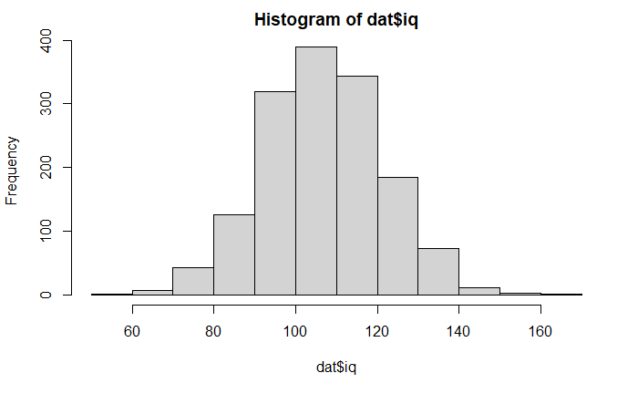

```r
hist(dat$iq)
```

That kinda looks normal, albeit ugly. A more advanced way of plotting the data uses the package *ggplot*. This allows us to create more complex, but also more beautiful plots, including but not limited to histograms. The most basic histogram of the same data as above looks as follows:

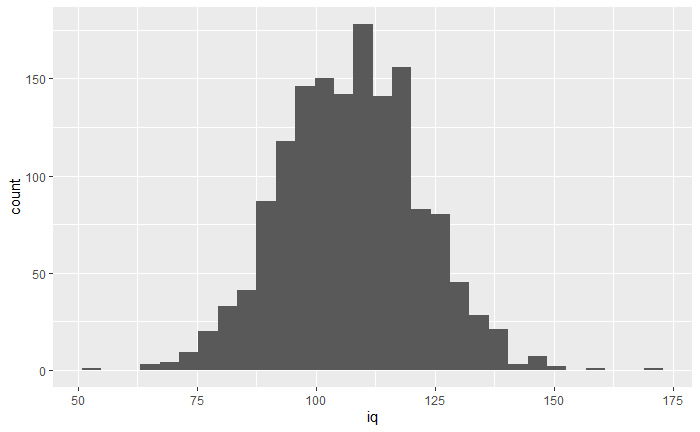

```r
library(ggplot2)
iq_hist <- ggplot(dat, aes(iq)) + geom_histogram()
iq_hist
```

How does the code work? the *ggplot()* function creates a new plot, with *dat* as argument. *aes()* defines what data is plotted, this can be more than this one dimension, for example if we want to plot the relationship of two variables, but here we just plot *iq*. Finally, we decide what is plotted by adding *geom_histogram()* to it, which unsurprisingly adds a histogram.

Bear in mind that the distribution doesn’t necessarily look the same as the first one and can look quite weird due to the choice of *bins*, which is the number of segments we distribute the data into. That doesn’t mean it is not normally distributed though. We can change the number of bins by changing the *bin*-parameter.You should then also understand what “bins” refers to :)

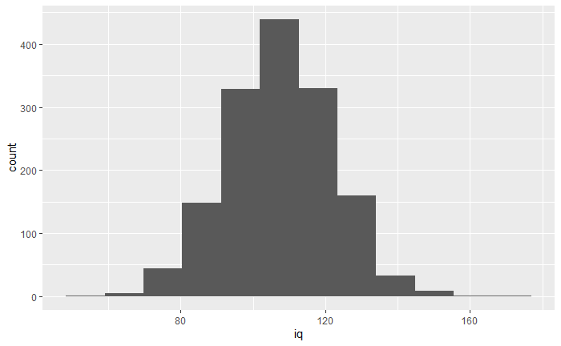

```r
iq_hist <- ggplot(dat, aes(iq)) + geom_histogram(bins = 12)
iq_hist
```

With 12 bins, you can see that the data looks scarily gaussian, however we obviously also compressed the data into less bins, so any weirdness within any of those bins wouldn’t be represented in this histogram.

To get an even better visualization of the distribution, not having to rely on those histogram-bins, let’s check the *geom_density()*, which is a more continuous density estimation of the data.

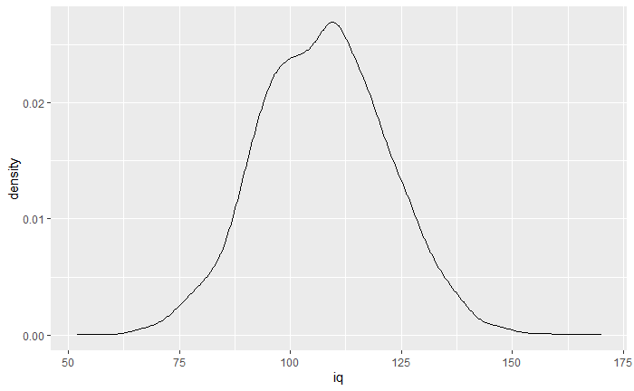

```r
iq_dens <- ggplot(dat, aes(iq)) + geom_density()
iq_dens
```

This looks quite normal indeed! A further option to check normality is to plot a Quantile-Quantile, or Q-Q Plot. Again,without going into the theory, if the residuals which are represented as dots follow the line, it indicates a normal distribution.

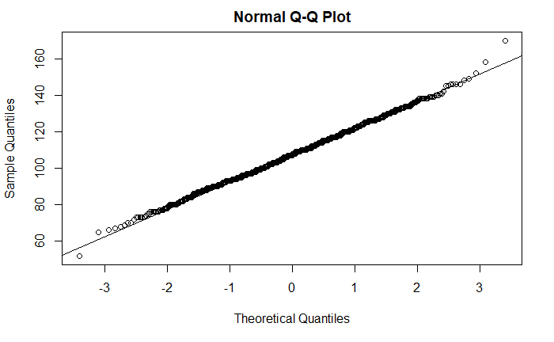

```r
qqnorm(dat$iq)
qqline(dat$iq)
```

That’s one (nearly) straight line!

We can further use different statistical tests to check if the sample is normally distributed. There are a lot of tests available and again, we are not going to go into the details of each of them, but will do one test of kurtosis and one test of skewness. We will use the *moments*-package for this:

```r
library(moments)

skewness(dat$iq)
```

```
[1] 0.07200287
```

```r
kurtosis(dat$iq)
```

```
[1] 3.142137
```

The data is unskewed at 0, so our skewness value is quite small, only indicating a minimal skew to the right, but not more than would be expected. A Kurtosis of 3 would be considered normal, so we are still in the range of what is expected. Different cutoff points have been described for what is acceptable, but they are ultimately highly debatable.

```r
shapiro.test(dat$iq)
```

```
    Shapiro-Wilk normality test

data:  dat$iq
W = 0.99834, p-value = 0.1463
```

As the Shapiro-Wilk normality test does not return significant, we can assume that the distribution is indeed normal.

Again, limitations of different normality tests are important to note and not part of this tutorial.

# Investigating Schizo and Creativity Scores

Now it’s your turn again! We will investigate the test score distributions participants scored on both the schizophreny test and the creativity test. Let’s first plot the histogram of the *schizo_scores* using *ggplot*.

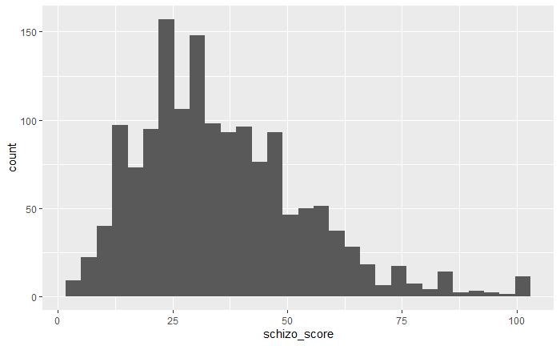

```r
schizo_hist <- ggplot(dat, aes(schizo_score)) + geom_histogram()
schizo_hist
```

This looks a bit skewed to the right, doesn’t it? Let’s check with a density plot!

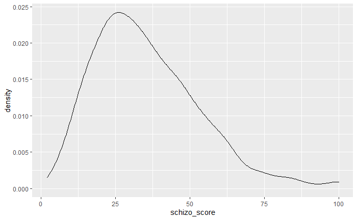

```r
schizo_dens <- ggplot(dat, aes(schizo_score)) + geom_density()
schizo_dens
```

We can now check the skewedness and kurtosis statistically, as we have done before:

## Correcting for non-normality!

Again, ignoring limitations and theoretical backgrounds, we can correct for a right skew by taking the square root of each value, using the function *sqrt()*. We will create a new column, called *schizo_norm* for these unskewed values (although they have technically not been normalized).

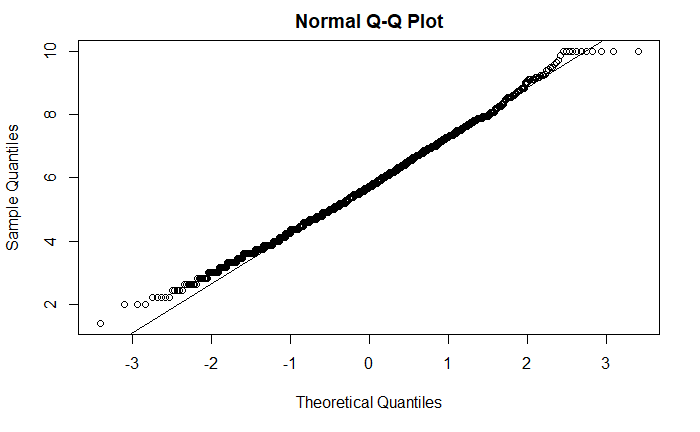

```r
dat$schizo_norm <- sqrt(dat$schizo_score)
qqnorm(dat$schizo_norm)
qqline(dat$schizo_norm)
```

Doesn’t look perfect, but certainly a lot less skewed! Again, before you correct for skewness in real-life applications, always make sure that it is statistically valid, as well as necessary, as not all models actually require you to have normally distributed data. Let’s check the Shapiro-Wilks value:

```r
shapiro.test(dat$schizo_norm)
```

```
    Shapiro-Wilk normality test

data:  dat$schizo_norm
W = 0.99584, p-value = 0.0003967
```

Well, it’s still not normal and we could fine-tune the data more, but this will do for our purposes. In real-life applications though, rather pay attention to what your tests require the data to look like. Often, non-normal data does not prohibit an analysis, but rather has to be seen as a limitation, and often there are alternatives to well-known tests available which do not require you to have normally distributed data at all.

Due to time constraints (and the complexity of the variable… trust me…) we won’t take a look at creativity scores, but don’t ever do that in real analyses!

# Distribution of Categorical Variables

Let’s take a look at the distribution of the categorical variables. A good visual indication of the distribution of categorical variables comes through a barplot. Let’s investigate how education is distributed amongst our participants:

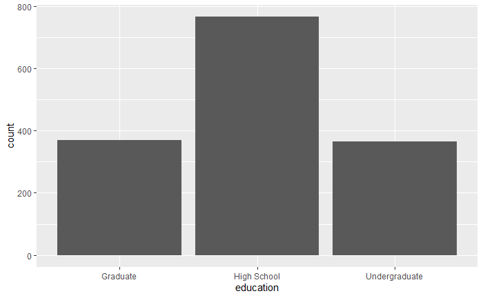

```r
edu_barplot <- ggplot(dat, aes(education)) + geom_bar()
edu_barplot
```

A bit… grey, isn’t it? You can customize graphs in a lot of ways! You can specify the *fill*-parameter in the *aes()* to “fill” the colors according to the values of the input variable/column, which also automatically creates a legend:

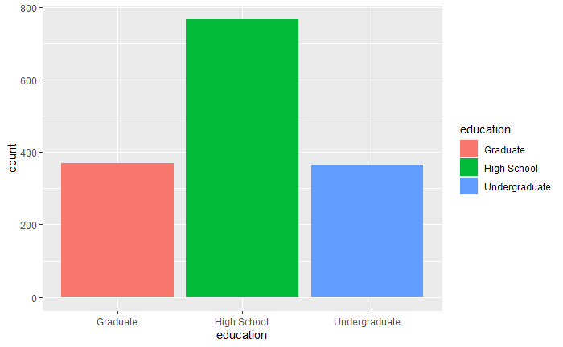

```r
edu_barplot <- ggplot(dat, aes(education, fill=education)) + geom_bar()
edu_barplot
```

## Investigating Sex and Gaming

In the same way, let us investigate the distribution of the categorical variables “sex” and “gaming”. First, create a barplot of your liking of the variable “sex”:

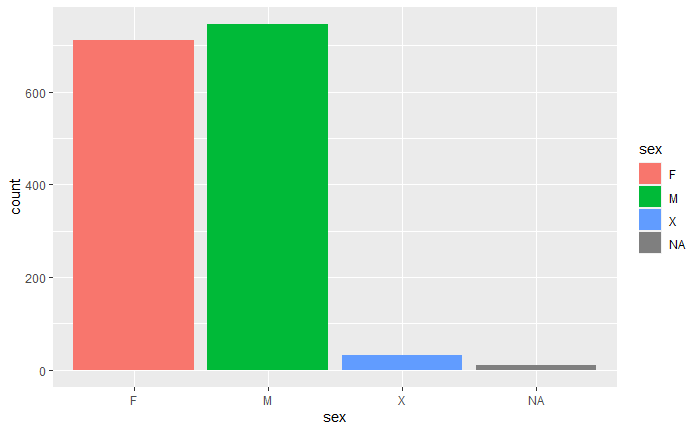

```r
sex_barplot <- ggplot(dat, aes(sex, fill=sex)) + geom_bar()
sex_barplot
```

Looks relatively evenly distributed between males and females, with some missing and some “other” values chosen.

Now, do the same with the gaming variable:

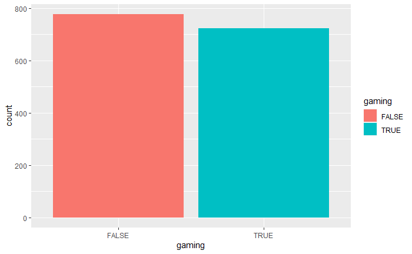

```r
gaming_barplot <- ggplot(dat, aes(gaming, fill=gaming)) + geom_bar()
gaming_barplot
```

Seems like the majority is not into gaming, although we will not statistically test this assumption.

After getting a basic overview over the data, it’s now time to do some statistical magic!

# Effect of Sex on Creativity

Have you ever wondered whether men or women are more creative? Me neither! Let’s check it anyway, using one of the most basic test available to us, a t-test, and plotting the result. We will carelessly ignore the existence of other sex identities for this analysis, cause t-tests are really socially unwoke insensitive binary tests, booo!

## T Test

Let’s to a Welch Two Sample t-test, simply done by using *t.test()*. For this, we now need to understand how statistical models in R work. What we are interested in is, how the dependent variable *creative_task* depends on the variable *sex*. In R, we first write the dependent variable, then a *~*, meaning “depends on” and then add the formula we want to check, in this case just the very simple variable *sex*. The formula therefore is *creative_task ~ sex*. Now, we need to also restrict our data to cases where the sex equals Male or Female and do this by restricting *dat* to instances where *dat$sex* is in the list *c(“M”, “F”)*, which can be checked using *%in%*. That excludes all rows where the sex-column either is not available, NA, or other, X.

```r
t.test(creative_task ~ sex, data = dat[dat$sex %in% c("M", "F"),])
```

```
    Welch Two Sample t-test

data:  creative_task by sex
t = -3.5659, df = 1448.8, p-value = 0.0003743
alternative hypothesis: true difference in means between group F and group M is not equal to 0
95 percent confidence interval:
 -0.7225217 -0.2097087
sample estimates:
mean in group F mean in group M
       4.419944        4.886059
```

By golly, the mean on the creativity test for men is higher than for women and the p-value is below .05, meaning the difference is statistically significant! That must mean that men are more creative, we’ve settled a thousands-years old debate no one cared about! Right…? Well, let’s first visualize this result, before we further evaluate it.

One option to plot differences between groups is the *pirateplot*. This is a modified version of a boxplot with some neat extras, which you will see in the following:

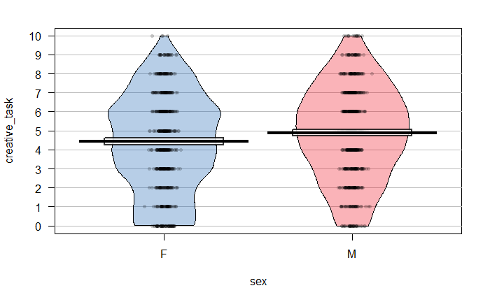

```r
library(yarrr)
pirateplot(formula = creative_task ~ sex, data = dat[dat$sex %in% c("M", "F"),])
```

The pirateplot is defined using the same formula as used in the t-test, neat! The resulting plot has multiple insightful elements. You can see the different instances of values as points, which isn’t of much help here considering the vast amount of values on each score. Therefore, we have a *bean*, which is the surrounding, colored density curve representing the distribution of data, obviously thickening in the middle and thinning out on the outside. Further, we have the black, thick line in the middle, representing the mean, and barely visible, the band, the only slightly visible rectangle surrounding the mean, which represents the confidence interval. The reason for why the confidence interval is not much visible here is simply that it’s narrow, so we have enough data to be confident that the mean is quite accurate. The plot itself shows us that, indeed, men scored better than women, albeit not by a lot, but still significantly so. So, are men more creative than women? We will postpone that question to later…

We will abandon the discussion about sex and gender here, but will return soon!

# Effect of Gaming on Creativity

It’s your turn now! Let’s investigate the effect of gaming on creativity, the same way we investigated the effect of sex on it.

Let us first do a Welch’s t-test to check whether there are differences between gamers and non-gamers in regards to the creativity scores. Do this now and check the results after. Be aware that for this, we can use the whole dataset *dat* and DO NOT have to restrict it to male and female participants:

# Effect of IQ on Creativity

## Linear Model Time!

One thing we would definitely be interested in is: Do more intelligent people show higher levels of creativity? A simple model to check this is checking the effect that iq has on the creativity score, using a linear regression model. In R, these can simply be created using *lm()*

```r
m1 <- lm(creative_task ~ iq, data=dat)
summary(m1)
```

```
Call:
lm(formula = creative_task ~ iq, data = dat)

Residuals:
    Min      1Q  Median      3Q     Max
-7.2167 -1.4135  0.0674  1.4063  5.2751

Coefficients:
             Estimate Std. Error t value Pr(>|t|)
(Intercept) -6.487866   0.385150  -16.84   <2e-16 ***
iq           0.103822   0.003554   29.21   <2e-16 ***
---
Signif. codes:  0 ‘***’ 0.001 ‘**’ 0.01 ‘*’ 0.05 ‘.’ 0.1 ‘ ’ 1

Residual standard error: 1.996 on 1498 degrees of freedom
Multiple R-squared:  0.3629,    Adjusted R-squared:  0.3625
F-statistic: 853.2 on 1 and 1498 DF,  p-value: < 2.2e-16
```

You can see that the iq-coefficient returns highly significant, indeed indicating that a higher iq leads to a higher amount of creativity! We can also plot this using ggplot:

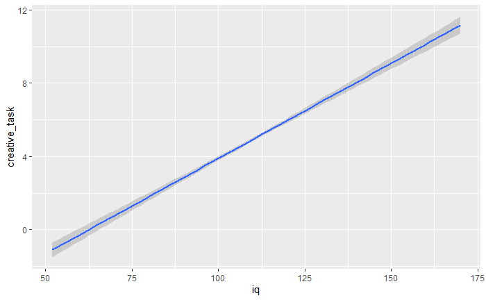

```r
iq_creat_lm <- ggplot(dat, aes(iq, creative_task)) + geom_smooth(method=lm)
iq_creat_lm
```

Using ggplot, we can see that the linear model seems highly significant and that, the more intelligent one is, the more creative. It is however recommendable to not blindly just fit a linear model, but add a scatterplot, actually plotting all individual values to see whether the model actually fits well. We can easily add the scatterplot by using *geom_point()*:

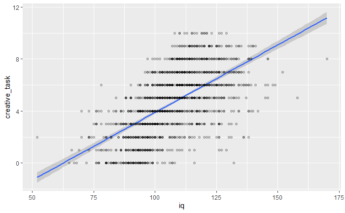

```r
iq_creat_lm + geom_point(alpha=0.2)
```

# Trying a Generalized Additive Model (GAM):

Therefore, we will test a Generalized Additive Model (GAM). If you’ve never heard of this, don’t despair, it’s quite an advanced model, although consider it valuable when working with statistical models, these models are very powerful!

We will not go much into details, but a GAM allows you to use a non-linear regression and even test multiple predictors at once in a complex fashion. Let us just fit and visualize a GAM-model, so you can see what it does and how it works approximately.

We use the *gam()*-function from the *mgcv*-package. we again depend the *creative_task* on the *iq*, however we use iq as a *smooth term*, by putting it within the *s()*-function, setting *“cr”* as a *bs*, meaning that we base the smooth term on a cubic spline. We will not explain what this means, because setting these terms well is… hard, and a bit of an art. However, this is a default choice which should give us a decent model.

```r
library(mgcv)
m2 <- gam(creative_task ~ s(iq, bs="cr"), data=dat)
summary(m2)
```

```
Family: gaussian
Link function: identity

Formula:
creative_task ~ s(iq, bs = "cr")

Parametric coefficients:
            Estimate Std. Error t value Pr(>|t|)
(Intercept)  4.66133    0.04855   96.01   <2e-16 ***
---
Signif. codes:  0 ‘***’ 0.001 ‘**’ 0.01 ‘*’ 0.05 ‘.’ 0.1 ‘ ’ 1

Approximate significance of smooth terms:
        edf Ref.df     F p-value
s(iq) 5.946  7.168 159.8  <2e-16 ***
---
Signif. codes:  0 ‘***’ 0.001 ‘**’ 0.01 ‘*’ 0.05 ‘.’ 0.1 ‘ ’ 1

R-sq.(adj) =  0.434   Deviance explained = 43.6%
GCV = 3.5521  Scale est. = 3.5356    n = 1500
```

Similar to our linear model, we can see that the p-value is highly significant. We will not explain any of the other terms, but you can of course look them up. To test whether our second model is actually an improvement over the first, we can compare both models using the *anova()* function, which compares different models and checks whether one model is a significant improvement over another model.

```r
anova(m1, m2)
```

```
Analysis of Variance Table

Model 1: creative_task ~ iq
Model 2: creative_task ~ s(iq, bs = "cr")
  Res.Df    RSS     Df Sum of Sq      F    Pr(>F)
1 1498.0 5965.9
2 1493.1 5278.9 4.9463       687 39.283 < 2.2e-16 ***
---
Signif. codes:  0 ‘***’ 0.001 ‘**’ 0.01 ‘*’ 0.05 ‘.’ 0.1 ‘ ’ 1
```

And indeed, you can see that the amount of residuals in the second model are lower than in the first and that this difference is significant. This means that the GAM-model is significantly better at explaining the relationship between IQ and creativity than the Linear Model.

Let’s now visualize the gam, showing you what exactly it looks like:

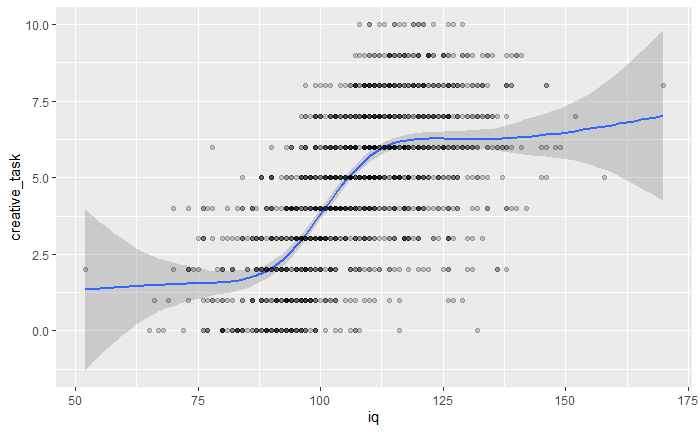

```r
iq_creat_lm <- ggplot(dat, aes(iq, creative_task)) + geom_smooth(method="gam") + geom_point(alpha=0.2)
iq_creat_lm
```

Due to the low amount of data at the respective ends we see a much larger confidence interval than in the middle, but the general model and trend shows that iq really only improves creativity up to about a score of 115, then it levels off. The model itself does not just create a linear line, but instead a smooth curve trying to estimate the curvature of the regression line, which in this case does not seem linear.

The levelling off effect of IQ on creativity, by the way, is an actual scientific observation (even though this data is artificial). Therefore, always make sure that you find the optimal model and don’t just go with a linear model, even if it seems fitting.

# Effect of Schizophreny on Creativity

You know the drill, now it’s time for you to do repeat the analysis we did before, but on another variable! We will check the effect of the schizophreny scores on creativity. Does it relate? Are Schizophrenic people more creative? Let’s see…

First, create a basic linear model with *lm()* to investigate the effect of the *schizo_score* in creativity and investigate the summary. Why do we not use that beautiful *schizo_norm* which we’ve created? Because… we don’t really need to, and this way we can easily investigate how the actual test scores influence creativity without having to transform the scores back.

```r
m3 <- lm(creative_task ~ schizo_score, data=dat)
summary(m3)
```

```
Call:
lm(formula = creative_task ~ schizo_score, data = dat)

Residuals:
   Min     1Q Median     3Q    Max
-7.083 -1.620  0.179  1.810  5.247

Coefficients:
             Estimate Std. Error t value Pr(>|t|)
(Intercept)  3.325048   0.138575   24.00   <2e-16 ***
schizo_score 0.037585   0.003483   10.79   <2e-16 ***
---
Signif. codes:  0 ‘***’ 0.001 ‘**’ 0.01 ‘*’ 0.05 ‘.’ 0.1 ‘ ’ 1

Residual standard error: 2.408 on 1498 degrees of freedom
Multiple R-squared:  0.07212,   Adjusted R-squared:  0.0715
F-statistic: 116.4 on 1 and 1498 DF,  p-value: < 2.2e-16
```

…and then plot the same model with ggplot:

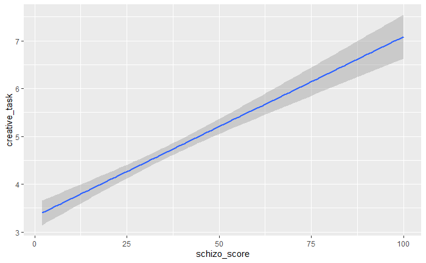

```r
schizo_creat_lm
```

Maybe we should also fit a GAM here, as we did before, and check the model summary as well. You can take the exact parameters we’ve used before:

```r
m4 <- gam(creative_task ~ s(schizo_score, bs="cr"), data=dat)
summary(m4)
```

```
Family: gaussian
Link function: identity

Formula:
creative_task ~ s(schizo_score, bs = "cr")

Parametric coefficients:
            Estimate Std. Error t value Pr(>|t|)
(Intercept)  4.66133    0.05451   85.52   <2e-16 ***
---
Signif. codes:  0 ‘***’ 0.001 ‘**’ 0.01 ‘*’ 0.05 ‘.’ 0.1 ‘ ’ 1

Approximate significance of smooth terms:
                  edf Ref.df     F p-value
s(schizo_score) 5.551  6.681 89.57  <2e-16 ***
---
Signif. codes:  0 ‘***’ 0.001 ‘**’ 0.01 ‘*’ 0.05 ‘.’ 0.1 ‘ ’ 1

R-sq.(adj) =  0.287   Deviance explained = 28.9%
GCV = 4.4759  Scale est. = 4.4564    n = 1500
```

…and visualize the GAM as well, you can even add the scatterplot into it immediately:

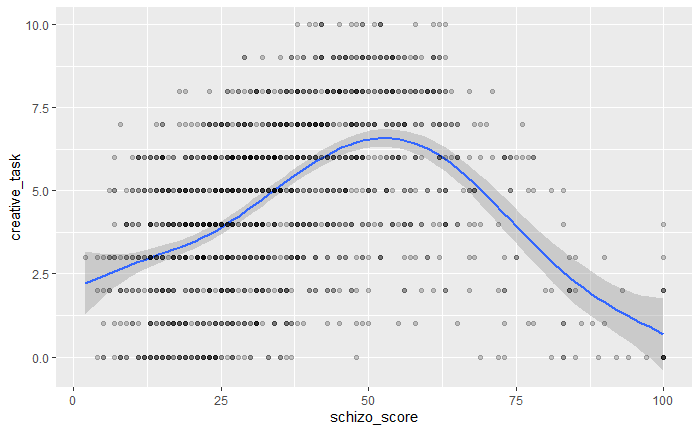

```r
schizo_creat_gam <- ggplot(dat, aes(schizo_score, creative_task)) + geom_smooth(method="gam") + geom_point(alpha=0.2)
schizo_creat_gam
```

# Revising Male Creativity Superiority! - Interaction Effects

Finally, let’s go back to the findings of gender creativity issues. Remember how we created a t-test, checking creativity differences between males and females? Similarly, we could just create a linear model representing this relationship. The reason for this will become apparent soon, let’s for now create a basic linear regression model using *lm()* with creativity as outcome and sex as independent variable and investigate the summary of the model. You remember how this is done, right?

Oh, and remember how annoying it was to copy and paste the sex-restriction over and over again, because we didn’t have enough data for the “others”? Well, we can just create a second version of our dataset to make it easier:

```r
dat2 <- dat[dat$sex %in% c("M", "F"),]
```

Just remember to use *dat2* for the following analyses. Now, create the linear model:

```r
m5 <- lm(creative_task ~ sex, data=dat2)
summary(m5)
```

```
Call:
lm(formula = creative_task ~ sex, data = dat2)

Residuals:
    Min      1Q  Median      3Q     Max
-4.8861 -1.8861  0.1139  1.9805  5.5801

Coefficients:
            Estimate Std. Error t value Pr(>|t|)
(Intercept)  4.41994    0.09345  47.298  < 2e-16 ***
sexM         0.46612    0.13064   3.568 0.000372 ***
---
Signif. codes:  0 ‘***’ 0.001 ‘**’ 0.01 ‘*’ 0.05 ‘.’ 0.1 ‘ ’ 1

Residual standard error: 2.494 on 1456 degrees of freedom
Multiple R-squared:  0.008667,  Adjusted R-squared:  0.007986
F-statistic: 12.73 on 1 and 1456 DF,  p-value: 0.0003715
```

We can see that, indeed, the male creativity scores are significantly higher than the female creativity scores, which is obviously what we already found with the t test. Let’s shortly visualize this model to see, how categorical independent variables look in a linear model. Pay attention to the sex being converted to a *numeric*, which was automatically done in the *lm()* function, but has to be manually done here:

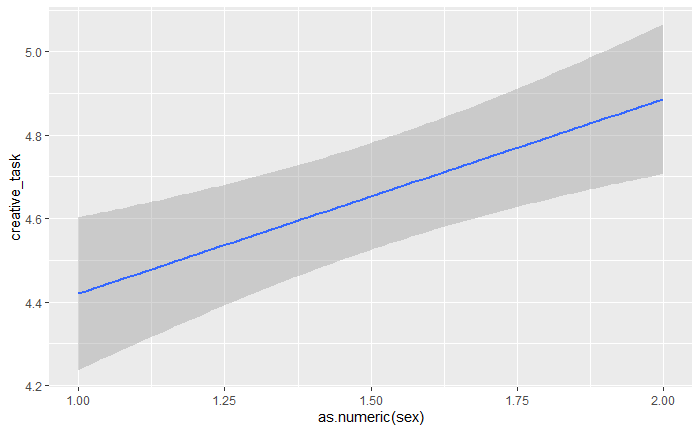

```r
sex_creat_lm <- ggplot(dat2, aes(as.numeric(sex), creative_task)) + geom_smooth(method=lm)
sex_creat_lm
```

Females are represented at the value 1, while males are represented at value 2. You can see that, indeed, there is a difference. The linear model then draws a line, although to be fair, even with gender fluidity in mind, any in-between values of 1.2 or 1.5, just exist mathematically, they bear no meaning for the real life interpretation of this categorical model.

## Investigating Interaction Effects.

You know… I suddenly remember that we found that gamers were actually more creative than non-gamers… hmmm… And based on my experience, males tend to game more than females, sooo… Is it possible, that the only reason why males were more creative is that they game more, and it is indeed not a consequence of biological differences?

We can test this by checking the *interaction* between two variables, namely the sex and gaming. Let’s look at the pirateplot of the sex differences in creativity again:

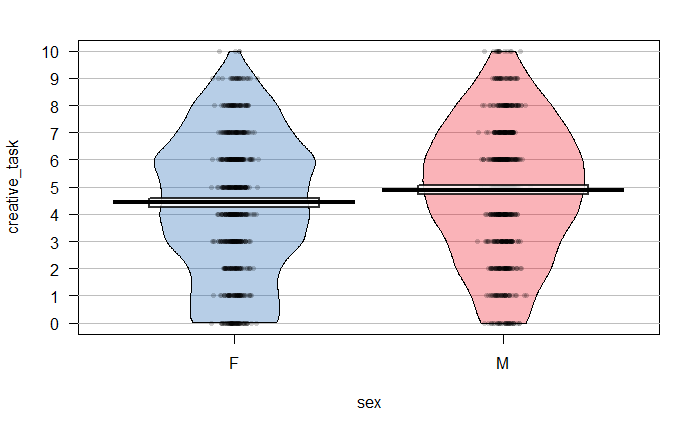

```r
pirateplot(formula = creative_task ~ sex, data = dat2)
```

And we also saw in the linear model that the respective means were 4.42 for females and 4.89 for males.

So, what we would be interested in, is: Are female gamers as creative as male gamers and female non-gamers as creative as male non-gamers? Let’s check the respective means by using *aggregate*. Aggregate allows us to aggregate data based on a formula, in this case sex and gaming, so *sex + gaming*. We then apply a function to the separated groups, which are four groups:

- Female Gamers
- Male Gamers
- Female Non-Gamers
- Male Non-Gamers

The function applied to the grouped data is *mean*, as we care about the mean creativity scores:

```r
genderized_insights <- aggregate(formula=creative_task ~ sex + gaming, data=dat2, FUN=mean)
genderized_insights
```

| sex | gaming | creative_task |
| --- | --- | --- |
| F | FALSE | 3.972387 |
| M | FALSE | 3.983264 |
| F | TRUE | 5.526829 |
| M | TRUE | 5.311637 |

The outcome shows that for non-gamers, both the female and male mean are nearly identical, and both female and male means for gamers are respectively higher. The female gamer mean is even a bit higher than the male one! This indicates, that the whole effect of males being more creative must probably have been caused by the higher amount of gamers, but we should still test this statistically and visualize it.

We can actually extend the pirateplot from above, separating it into the four mentioned categories, by checking the interaction. This is done using the star symbol, *. This has to be put in between two variables to check for their interaction. The plot then becomes the following:

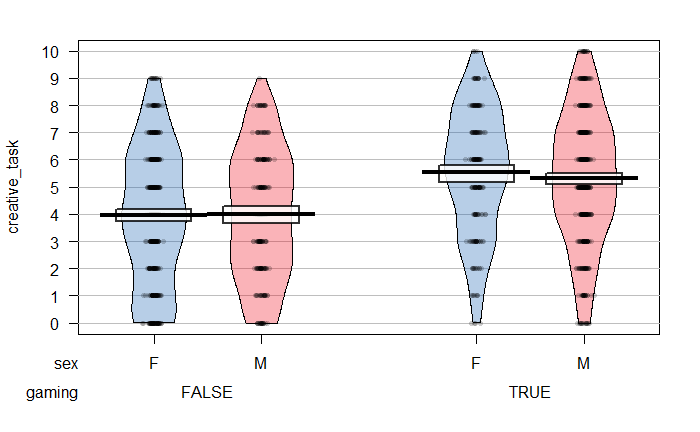

```r
pirateplot(formula = creative_task ~ sex * gaming, data = dat2)
```

This plot basically visualized what we’ve seen before, although due to the addition of confidence interval bands, we can see that the means between the gamers probably does not differ significantly.

We can now create a formal linear model using the same formula as in the pirateplot and check the summary. You do it, you have experience with this now :)

```r
m6 <- lm(creative_task ~ gaming * sex, data=dat2)
summary(m6)
```

```
Call:
lm(formula = creative_task ~ gaming * sex, data = dat2)

Residuals:
    Min      1Q  Median      3Q     Max
-5.5268 -1.9724  0.0276  2.0167  5.0276

Coefficients:
                Estimate Std. Error t value Pr(>|t|)
(Intercept)      3.97239    0.10683  37.184  < 2e-16 ***
gamingTRUE       1.55444    0.19910   7.807 1.11e-14 ***
sexM             0.01088    0.18874   0.058    0.954
gamingTRUE:sexM -0.22607    0.27434  -0.824    0.410
---
Signif. codes:  0 ‘***’ 0.001 ‘**’ 0.01 ‘*’ 0.05 ‘.’ 0.1 ‘ ’ 1

Residual standard error: 2.405 on 1454 degrees of freedom
Multiple R-squared:  0.07868,   Adjusted R-squared:  0.07678
F-statistic: 41.39 on 3 and 1454 DF,  p-value: < 2.2e-16
```

As you can see, there is no effect of sex, there is also no interaction effect between sex and gaming. The whole effect we observed in the linear model between the sexes originally stems from gaming. We were led afoot by the fact that there are more male gamers than female gamers!

Let’s shortly compare the last two models on their suitability, using an anova:

```r
anova(m5, m6)
```

```
Analysis of Variance Table

Model 1: creative_task ~ sex
Model 2: creative_task ~ gaming * sex
  Res.Df    RSS Df Sum of Sq      F    Pr(>F)
1   1456 9052.8
2   1454 8413.4  2    639.34 55.245 < 2.2e-16 ***
---
Signif. codes:  0 ‘***’ 0.001 ‘**’ 0.01 ‘*’ 0.05 ‘.’ 0.1 ‘ ’ 1
```

Unsurprisingly, the second model outperforms the first.

However, we can also just abandon the sex-term completely and compare whether it is still as good as the more complex model:

```r
m7 <- lm(creative_task ~ gaming, data=dat2)
summary(m7)
```

```
Call:
lm(formula = creative_task ~ gaming, data = dat2)

Residuals:
    Min      1Q  Median      3Q     Max
-5.3736 -1.9759  0.0241  2.0241  5.0241

Coefficients:
            Estimate Std. Error t value Pr(>|t|)
(Intercept)  3.97587    0.08805   45.16   <2e-16 ***
gamingTRUE   1.39772    0.12599   11.09   <2e-16 ***
---
Signif. codes:  0 ‘***’ 0.001 ‘**’ 0.01 ‘*’ 0.05 ‘.’ 0.1 ‘ ’ 1

Residual standard error: 2.405 on 1456 degrees of freedom
Multiple R-squared:  0.07794,   Adjusted R-squared:  0.0773
F-statistic: 123.1 on 1 and 1456 DF,  p-value: < 2.2e-16
```

```r
anova(m6, m7)
```

```
Analysis of Variance Table

Model 1: creative_task ~ gaming * sex
Model 2: creative_task ~ gaming
  Res.Df    RSS Df Sum of Sq      F Pr(>F)
1   1454 8413.4
2   1456 8420.2 -2    -6.779 0.5858 0.5568
```

You can see that there is no significant difference in how well these models perform. In this case, you should always opt for the simpler model, which indeed is model 7. Sex simply plays no role in explaining creativity.

Before we finish, a short comment on the realism of the last observations: Yes, there are more male gamers and yes, gamers have been found to be more creative, however: Even in this case, I am not sure whether males would actually outperform females, simply because females will on average have other hobbies that lead to higher creativity. The most plausible explanation for a result like this would be that the way we assess creativity is based on a test which somehow has aspects of creativity close to the one used in gaming, so the concept of creativity tested in this test would be biased towards gamers. Ultimately, the whole data here is simulated, so none of this is real anyway. Just be aware that results like these might actually happen and might mislead you to draw false conclusions!

I hope you found this workbook a helpful, insightful primer to R!

If you feel like going on, there is an extra task:

# EXTRA: CREATE AN AMAZING GAM!

Remember that GAM with the smooth schizophreny term? We can extend this with interactions (using *) as well as just using multiple predictors without interaction, using (+). Try to extend the model and find the perfect model explaining creativity! The obvious way to start is including the gaming variable we have found before, but you can always try more variables. There should indeed be a “perfect” model which isn’t too complex, but I’d be amazed if you found it :)

And as always: Google!